# Analiza i eksploracja danych tekstowych

12.08.2021

# Podejście, metodologia i etapy analizy:

- Użyto tekstu zawierającego internetowe opinie z dziedziny usług medycznych, hotelowych oraz badań naukowych / studiów
- Usunięto białe znaki, stopwordy oraz słowa krótsze niż trzy znaki
- Przy użyciu słownika form podstawowych sprowadzono poszczególne wyrazy do bezokolicznika lub mianownika l.poj.
- Z tekstu wyodrębniono oceny / labele, zgrupowano do je trzech kategorii sentymentu i przekształcono w zmienną objaśnianą y
- Macierz zmiennych objaśniających X przygotowano poprzez wektoryzację tekstu i przy użyciu n–gramów rzędu 1
- Jako model predykcyjny wydźwięku / sentymentu użyto algorytmu Lasu Losowego z uwagi na wieloklasową zmienną objaśnianą
- Model zoptymalizowano pod względem ilości estymatorów, maksymalizując miarę Accuracy i wykorzystując trzykrotną walidację krzyżową
- Dokonano oszacowania ilości grup tematycznych (topiców) w analizowanym tekście poprzez redukcję wymiarów zbioru do dwóch metodą TruncatedSVD i przez wizualną ocenę na wykresie
- Przygotowano model klasyfikacji danego wpisu do tematu (topicu) wykorzystując algorytm Ukrytej Alokacji Dirichleta LDA

# Statystyka opisowa próby

```
 Ilość wpisów: 3573
 Ilość znaków w tekście: 422978
 Ilość słów w tekście: 58060
 Ilość unikalnych słów w tekście: 11453

 Statystyka ilości słów we wpisach:
 Min: 1
 Max: 109
 Średnia: 16.25
 Mediana: 14.00
```

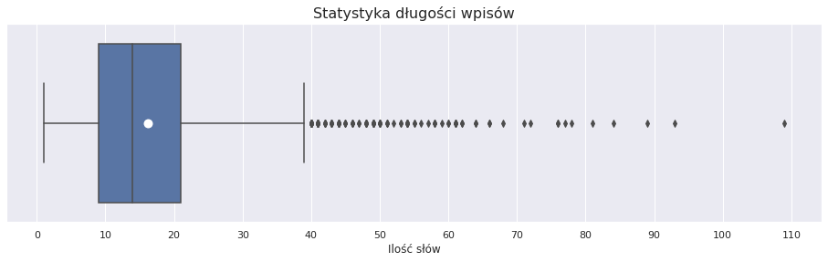

- Zwraca uwagę pewna liczba outlierów tzn. wpisów o dużej ilości słów, na tyle duża aby wpłynąć na wzrost średniej względem mediany
- Outliery zawarte w próbie uczącej potencjalnie mogą mieć wpływ na obniżenie efektywności uczonych na nich modeli
- Warto dodatkowo zbadać rozkład wydźwięku tych dłuższych wpisów aby rozważyć wprowadzenie nowej zmiennej ("długość wpisu") do modelu przewidującego sentyment

# Przegląd tematyki i liczebności słów

| Słowo | Liczebność |
| --- | --- |
| hotel | 358 |
| doktor | 246 |
| lekarz | 240 |
| pokój | 175 |
| wizyta | 141 |
| pacjent | 137 |
| polecać | 113 |
| czas | 112 |
| problem | 82 |
| niestety | 81 |
| obsługa | 75 |

- Dominuje słownictwo związane z usługami medycznymi i hotelarskimi
- Duża liczebność słów o negatywnym wydźwięku ("problem", "niestety") potwierdza tezę o częstszym wpisywaniu komentarzy przez osoby niezadowolone niż zadowolone
- Większy udział komentarzy negatywnych niż pozytywnych o blisko dziesięć punktów procentowych
- Dokładny wydźwięk słowa "polecać" warto zbadać w kontekście n-gramu rzędu 2 - czy jest poprzedzone słowem "nie"

|  | Liczba | Odsetek |
| --- | --- | --- |
| minus | 1395 | 39.0 |
| plus | 1044 | 29.2 |
| zero | 1134 | 31.7 |

# Wizualna weryfikacja tematów tekstu

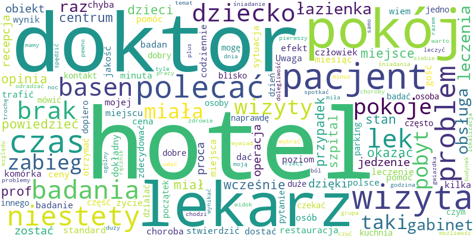

# Algorytm klasyfikacji - wykrywania wydźwięku wypowiedzi

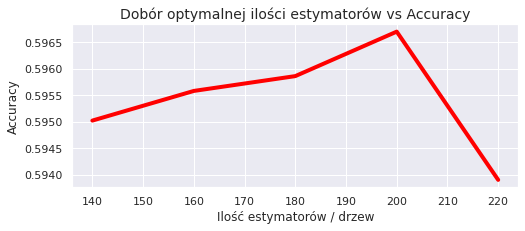

```
Accuracy po optymalizacji = 0.597
Ważony F1 po optymalizacji = 0.588
```

- Wykorzystany algorytm Lasu Losowego pozwala uzyskać stabilne, powtarzalne rezultaty oszacowań, jest też dość szybki w obliczeniach, daje się zrównoleglać i pozwala na łatwe wyjaśnienie odbiorcom biznesowym mechanizmu jego działania
- Jego słabą stroną jest niska dokładność, wynik niewiele wyższy od rezultatu losowego, nawet po optymalizacji ilości klasyfikatorów
- Użycie odwróconej częstości występowania słów TFIDF do wektorowania słów, miary Entropii zamiast miary Giniego jako kryterium podziału w węzłach oraz zwiększenie rzędu n-gramów w wektoryzacji do 2 i 3 nie podniosło efektywności modelu

# Macierz błędów

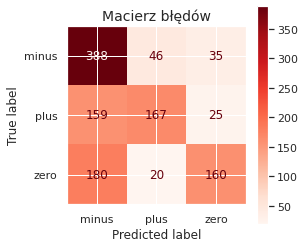

- Głównym czynnikiem wpływającym na niską dokładność klasyfikacji jest nadmierne przypisywanie innych klas do kategorii "minus", czyli nadmierny "pesymizm" modelu
- Optymalizacja kolejnych parametrów modelu, zwiększenie próby uczącej oraz usunięcie skrajnych, najdłuższych i najkrótszych wpisów powinno wpłynąć na zwiększenie dokładności
- Należy rozważyć wykorzystanie algorytmów drzewiastych wzmacnianych, takich jak XGBoost, LightGBM lub Catboost
- Dalszą poprawę wykrywania wydźwięku wypowiedzi można będzie również uzyskać przez zgrupowanie wpisów wg ich tematów i przeuczenie modelu na osobnych próbach monotematycznych

# Wyznaczanie i alokacja do grup tematycznych

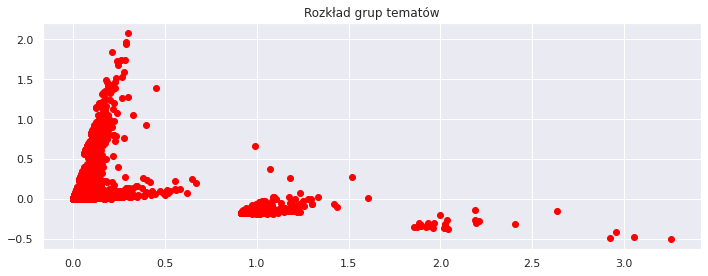

- Wykres ukazuje rozrzut próby po redukcji do dwóch wymiarów metodą TruncatedSVD
- Wizualna analiza wskazuje na występowanie trzech wyraźnie odrębnych znaczących grup tematycznych (bardzo nielicznej czwartej grupy)
- Zatem należy wykonać badanie dotyczące struktury słów w poszczególnych grupach, np. przy pomocy algorytmu LDA

# Ukryta Alokacja Dirichleta LDA

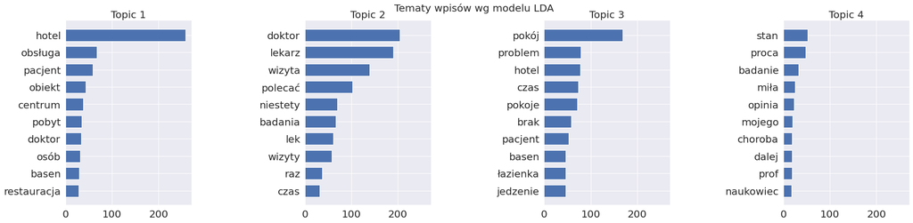

- Efektywny i intuicyjny podział przez LDA wystąpił dla tematów: usługi medyczne i hotelowe, licznie reprezentowane w tekstach)
- Wpisy dotyczące hotelarstwa zostały zróżnicowane aż na dwa obszary (Topic 1 i 3) z uwagi na największy udział wpisów w próbie - ponad 56%
- Temat dot. badań uniweryteckich (Topic 4) ma niższą reprezentację w tekstach, ale również jest wyodrębniany przez algorytm LDA

|  | Liczba | Odsetek |
| --- | --- | --- |
| Topic1 | 928 | 26.0 |
| Topic2 | 1003 | 28.1 |
| Topic3 | 1090 | 30.5 |
| Topic4 | 552 | 15.4 |

# Wykorzystanie biznesowe algorytmów użytych w analizie

- Algorytm klasyfikowania tematów, taki jak LDA, można wykorzystać do ustalania tematu rozmowy klienta z voicebootem (po transkrypcji głosu) i do sterowania przełączaniem gałęzi drzewa tematów rozmowy
- Innym zastosowaniem może być automatyczne sortowanie korespondencji elektronicznej
- Natomiast mechanizm wykrywania wydźwięku komentarza znajdzie wykorzystanie w marketingu, do analizy ocen produktu lub usługi przez klientów
- Pozwoli również na wyznaczanie grup klientów, do których należy zaadresować specyficzną ofertę lub działanie promocyjne
- Wykrywanie sentymentu tekstów raportów ekonomicznych może wspomóc proces ustalania poziomu ryzyka kredytowego w poszczególnych branżach